# Lab week 12 - Stacking

Data Science and Machine Learning 2 - CEU 2018

Jeno Pal

2018-03-20

```r
library(data.table)
library(GGally)
library(h2o)
h2o.init()
```

```
 Connection successful!

R is connected to the H2O cluster:
    H2O cluster uptime:         1 hours 30 minutes
    H2O cluster version:        3.16.0.2
    H2O cluster version age:    3 months and 20 days !!!
    H2O cluster name:           H2O_started_from_R_User_tvz954
    H2O cluster total nodes:    1
    H2O cluster total memory:   1.27 GB
    H2O cluster total cores:    8
    H2O cluster allowed cores:  8
    H2O cluster healthy:        TRUE
    H2O Connection ip:          localhost
    H2O Connection port:        54321
    H2O Connection proxy:       NA
    H2O Internal Security:      FALSE
    H2O API Extensions:         Algos, AutoML, Core V3, Core V4
    R Version:                  R version 3.4.3 (2017-11-30)
```

```
Your H2O cluster version is too old (3 months and 20 days)!
Please download and install the latest version from http://h2o.ai/download/
```

Stacking:

- specify different $L$ predictive models
- score training observations using out-of-fold predictions
- this gives a “level-one” data: the original outcome and the scores coming from the $L$ base models
- use these to estimate a second level predictive model (“meta-learner”)

When predicting new observations

- the base models are estimated using all training observations, use these to get scores for the new observation
- input this to the meta-learner model to get the predicted outcome

The more uncorrelated predictions are, the more room there is to improve individual models.

Stacked models do not always perform better than individual ones but many times they do.

You have seen how to do stacking with `caret` in the lecture. It is very convenient to create stacked ensembles in h2o, we are gaining practice with this now. See more [here](http://docs.h2o.ai/h2o/latest-stable/h2o-docs/data-science/stacked-ensembles.html).

```r
data <- h2o.importFile("../../data/airlines/airline100K.csv")
data_split <- h2o.splitFrame(data, ratios = 0.7, seed = 123)
data_train <- data_split[[1]]
data_test <- data_split[[2]]
y <- "dep_delayed_15min"
X <- setdiff(names(data_train), y)
```

Train some base learners using cross validation.

```r
glm_model <- h2o.glm(
  X, y,
  training_frame = data_train,
  family = "binomial",
  alpha = 1,
  lambda_search = TRUE,
  seed = 123,
  nfolds = 5,
  keep_cross_validation_predictions = TRUE
)
```

```r
gbm_model <- h2o.gbm(
  X, y,
  training_frame = data_train,
  ntrees = 200,
  max_depth = 10,
  learn_rate = 0.1,
  seed = 123,
  nfolds = 5,
  keep_cross_validation_predictions = TRUE
)
```

```r
deeplearning_model <- h2o.deeplearning(
  X, y,
  training_frame = data_train,
  hidden = c(32, 8),
  seed = 123,
  nfolds = 5,
  keep_cross_validation_predictions = TRUE
)
```

```r
ensemble_model <- h2o.stackedEnsemble( # built in h2o function, it estimates the meta model
                                       # on the scores estimated by the previously trained models
  X, y,
  training_frame = data_train,
  base_models = list(glm_model,
                     gbm_model,
                     deeplearning_model))
```

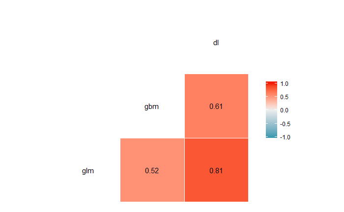

```r
# inspect test set correlations of scores
predictions <- data.table(
  "glm" = as.data.frame(h2o.predict(glm_model, newdata = data_test)$Y)$Y,
  "gbm" = as.data.frame(h2o.predict(gbm_model, newdata = data_test)$Y)$Y,
  "dl" = as.data.frame(h2o.predict(deeplearning_model, newdata = data_test)$Y)$Y
)
ggcorr(predictions, label = TRUE, label_round = 2)
```

```r
# test set performances
print(h2o.auc(h2o.performance(glm_model, newdata = data_test)))
```

```
[1] 0.7115506
```

```r
print(h2o.auc(h2o.performance(gbm_model, newdata = data_test)))
```

```
[1] 0.710618
```

```r
print(h2o.auc(h2o.performance(deeplearning_model, newdata = data_test)))
```

```
[1] 0.7238849
```

```r
# for the ensemble model
print(h2o.auc(h2o.performance(ensemble_model, newdata = data_test)))
```

```
[1] 0.7356249
```

The baseline meta-learner is a glm model. You can try others:

```r
ensemble_model_gbm <- h2o.stackedEnsemble(
  X, y,
  training_frame = data_train,
  metalearner_algorithm = "gbm",
  base_models = list(glm_model,
                     gbm_model,
                     deeplearning_model))
```

```r
print(h2o.auc(h2o.performance(ensemble_model_gbm, newdata = data_test)))
```

```
[1] 0.7379917
```

Meta-learning can also be built upon same-family, different hyperparameter models via a grid of hyperparameters.

```r
learn_rate_opt <- c(0.1, 0.3)
max_depth_opt <- c(3, 5, 7)
hyper_params <- list(learn_rate = learn_rate_opt,
                     max_depth = max_depth_opt)
gbm_grid <- h2o.grid(
  x = X, y = y,
  training_frame = data_train,
  algorithm = "gbm",
  ntrees = 10,
  hyper_params = hyper_params,
  seed = 123,
  nfolds = 5,
  keep_cross_validation_predictions = TRUE)
```

```r
ensemble_model_grid_gbm <- h2o.stackedEnsemble(
  X, y,
  training_frame = data_train,
  base_models = gbm_grid@model_ids)
```

```r
# individual test set performances
for (model_id in gbm_grid@model_ids) {
  model <- h2o.getModel(model_id)
  print(model_id)
  print(h2o.auc(h2o.performance(model, newdata = data_test)))
}
```

```
[1] "Grid_GBM_RTMP_sid_a628_9_model_R_1521563920336_455_model_1"
[1] 0.7194211
[1] "Grid_GBM_RTMP_sid_a628_9_model_R_1521563920336_455_model_3"
[1] 0.7180956
[1] "Grid_GBM_RTMP_sid_a628_9_model_R_1521563920336_455_model_4"
[1] 0.7142674
[1] "Grid_GBM_RTMP_sid_a628_9_model_R_1521563920336_455_model_2"
[1] 0.7178767
[1] "Grid_GBM_RTMP_sid_a628_9_model_R_1521563920336_455_model_5"
[1] 0.712203
[1] "Grid_GBM_RTMP_sid_a628_9_model_R_1521563920336_455_model_0"
[1] 0.7129126
```

```r
print(h2o.auc(h2o.performance(ensemble_model_grid_gbm, newdata = data_test)))
```

```
[1] 0.7263568
```